# Optional Stopping

Sau-Chin Chen

2016年10月23日

Remake from *Assignment 3.2: Optional Stopping*

The Type 1 error rate in behavioral research (the probability of saying there is an effect, when there is no effect) is often set at 0.05. In recent years, researchers have become increasingly aware of research practices that inflate the Type 1 error rate. This means that the true Type 1 error rate is higher, or inflated, above the nominal Type 1 error rate set by the researcher. *Simmons, Nelson, and Simonsohn (2011)* describe a number of research practices that lead to a situation where researchers are likely to say there is an effect, when there is no effect (i.e., make a Type 1 error) more than 5% of the time, in the long run. In essence, all these practices have to do with multiple comparisons – looking at your data multiple times, or performing a significance test for the same hypothesis in several different ways.

Here, we will focus on one way in which multiple comparisons inflate the Type 1 error rate known as **optional stopping**. In optional stopping, a researcher repeatedly analyzes the data, continues the data collection when the test result is not statistically significant, but stops when a significant effect is observed. We will learn why optional stopping can be efficient, but that you have to do it right, by **controlling the Type 1 error rate**.

Let’s first take a look how *p-value*s behave as you collect data. Open the PlotSingle*p-value*OverTime.R script and run it. This script will simulate an ongoing data collection. After 10 participants in each condition, a *p-value* is calculated by performing an independent t-test, and this t-test is then repeated after every additional participant you collect. Then, all these *p-value*s are plotted as a function of the increasing sample size.

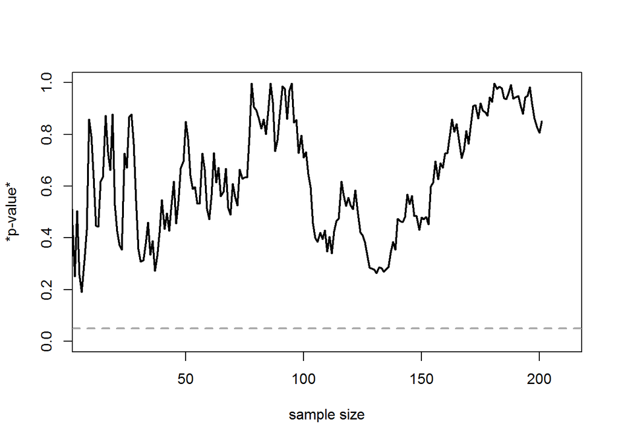

```r
n<-200 #total number of datapoints (per condition) you are willing to collect after initial 10

D<-0.0 #True effect size (Keep SD below to 1, otherwise, this is just mean dif, not d)
SD<-1 #Set True standard deviation.

p<-numeric(n) #store *p-value*s
x<-numeric(n) #store x-values
y<-numeric(n) #store y-values

n<-n+10 #script calculates *p-value*s after 10 people in each condition, so add 10 to number of datapoints
set.seed(1123) ## keep random numbers every time
for(i in 10:n){ #for each simulated participants after the first 10
  x[i]<-rnorm(n = 1, mean = 0, sd = SD)
  y[i]<-rnorm(n = 1, mean = D, sd = SD)
  z<-t.test(x[1:i],y[1:i], var.equal=TRUE) #perform the t-test
  p[i]<-z$p.value
}

p<-p[10:n] #Remove forst 10 empty *p-value*s

#Create the plot
#png(file="*p-value*_over_time.png",width=4000,height=2000, , units = "px", res = 500)
plot(0, col="red", lty=1, lwd=3, ylim=c(0,1), xlim=c(10,n), type="l", xlab='sample size', ylab='*p-value*', cex.lab=1, cex.axis=1)
lines(p, lwd=2)
abline(h=0.05, col="darkgrey", lty=2, lwd=2) #draw ine at p = 0.05
```

```r
#dev.off()

min(p) #Return lowest *p-value* from all looks
```

```
## [1] 0.1916023
```

```r
cat("The lowest *p-value* was observed at sample size",which.min(p)+10) #Return the sample size at which the *p-value* was smallest
```

```
## The lowest *p-value* was observed at sample size 16
```

```r
cat("The *p-value* dropped below 0.05 for the first time as sample size",which(p<0.05)[1]+10) #Return the sample size at which the *p-value* dropped below 0.05 for the first
```

```
## The *p-value* dropped below 0.05 for the first time as sample size NA
```

```r
#? Daniel Lakens, 2016.
# This work is licensed under a Creative Commons Attribution-NonCommercial-ShareAlike 4.0 International License. https://creativecommons.org/licenses/by-nc-sa/4.0/
```

For example, in the Figure above, you see the *p-value* plotted on the y-axis (from 0 to 1) and the sample size plotted on the x-axis (from 0 to 200). For this simulation, the true effect size (`D <- 0.0`) was 0, meaning there is no true effect. We can thus only observe true negatives or false positives. We will talk more about effect sizes in video 4.1, 4.2, and 4.3. For now, just know that the effect size expresses the strength of the effect you are examining.

If you only look at the data once (when all participants are collected) the *p-value* would fall below 0.05 only 5% of the time (given that the true effect size is 0). You can check whether the *p-value* drops below 0.05 in your simulation by looking at the graph, but the script also returns the lowest *p-value* for all looks.

Q1: Run the script 20 times, and count how often the lowest *p-value* ends up below 0.05 (we will calculate the long run probability of this happening through more extensive simulations later).

```r
cnt <- 20
round <- NULL
while(cnt > 0){
n<-200 #total number of datapoints (per condition) you are willing to collect after initial 10

D<-0.0 #True effect size (Keep SD below to 1, otherwise, this is just mean dif, not d)
SD<-1 #Set True standard deviation.

p<-numeric(n) #store *p-value*s
x<-numeric(n) #store x-values
y<-numeric(n) #store y-values

n<-n+10 #script calculates *p-value*s after 10 people in each condition, so add 10 to number of datapoints
for(i in 10:n){ #for each simulated participants after the first 10
  x[i]<-rnorm(n = 1, mean = 0, sd = SD)
  y[i]<-rnorm(n = 1, mean = D, sd = SD)
  z<-t.test(x[1:i],y[1:i], var.equal=TRUE) #perform the t-test
  p[i]<-z$p.value
}

p<-p[10:n] #Remove forst 10 empty *p-value*s
round <- c(round, sum(p < .05)/length(p))
cnt = cnt - 1
}
summary(round)
```

```
##    Min. 1st Qu.  Median    Mean 3rd Qu.    Max.
## 0.00000 0.00000 0.00000 0.02313 0.01119 0.24380
```

If there is a true effect, we can only observe a true positive or a false negative. Change the effect size on line 3 from `D <- 0.0` to `D <- 0.3`. This is a relatively small true effect, and with 200 participants in each condition, we have 85% power (or an 85% probability of finding a significant effect). Run the script again. Below is one possible example of the trajectory of *p-values* as the sample size increases.

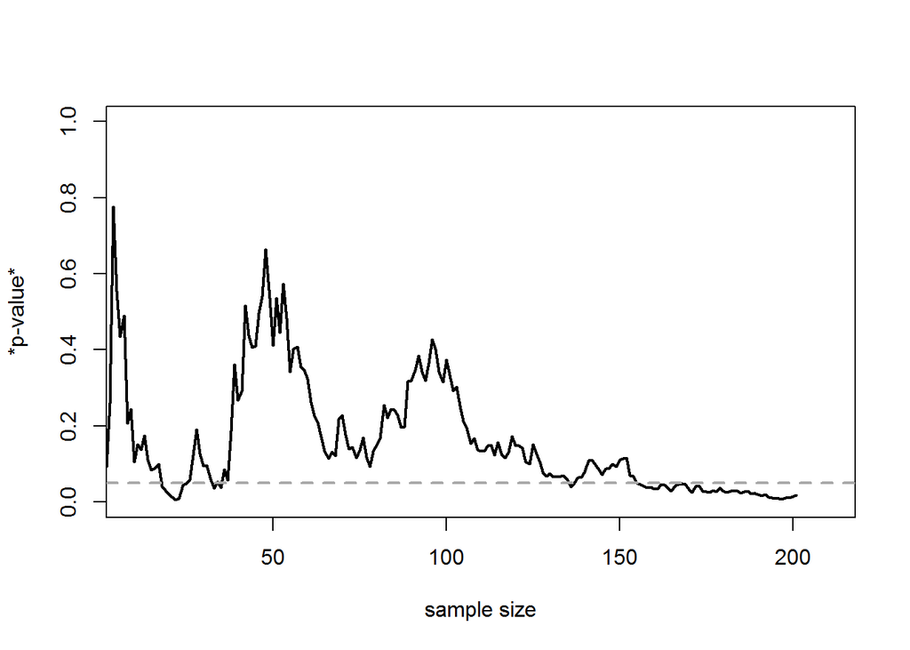

```
## [1] 0.005577673
```

```
## The lowest *p-value* was observed at sample size 32
```

```
## The *p-value* dropped below 0.05 for the first time as sample size 28
```

Q2: Run the script 20 times. Take a good look at the variation in the *p-value* trajectory. Remember that at N = 200, 85% of the times the *p-value* should have ended up below 0.05. The script returns the sample size the *p-value* is the lowest (which is often, but not always, at the maximum sample size, when there is a true effect) and the sample size at which the *p-value* drops below 0.05 for the first time. Which statement is true?

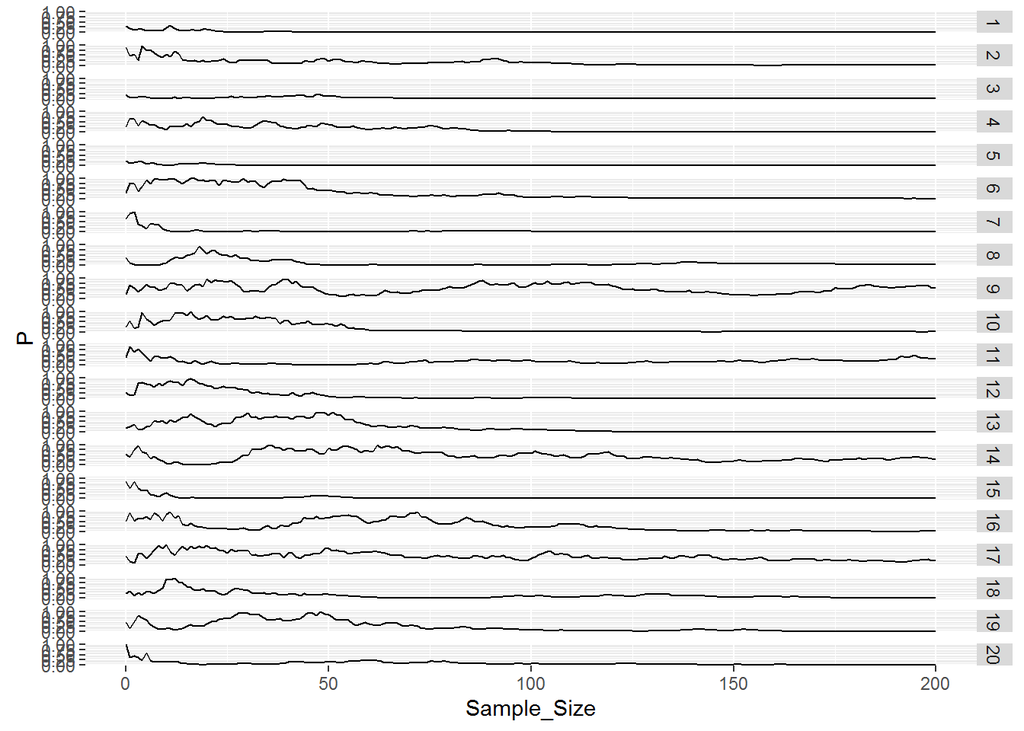

1. If the *p-value* drops below 0.05, it stays below 0.05.
2. The *p-value* randomly moves between 0 and 1, and will every now and then end up below 0.05.
3. The *p-value* often drops below 0.05 well before 200 participants in each condition. In around 50% of the simulations, this already happens at N = 100.  
   **D)** The *p-value* will typically move below 0.05 and stay there for some time, but given a large enough sample, it will always move back up to *p* > 0.05.

Q3: Change the effect size in line 3 to `D <- 0.8`, which can be regarded as a large effect. Run the script 20 times. Take a good look at the variation in the *p-value* trajectory. Which statement is true?

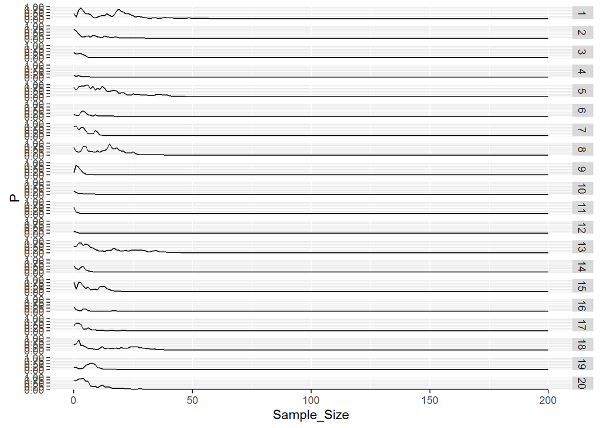

1. The *p-value* randomly moves between 0 and 1, and will every now and then end up below 0.05.
2. The *p-values* drop below and stay below 0.05 much earlier than when the true effect size is 0.3.
3. *p-values* are meaningful when effect sizes are large (e.g., d = 0.8), but meaningless when effect sizes are small (e.g., d = 0.3).
4. When you examine a large effect, whenever a *p-value* drops below 0.05, it always stays below 0.05 as the sample size increases.